# Welcome to the Diabetes Analytics dataset provided by the Behavioral Risk Factor Surveillance System (BRFSS). Using all tools available to you, analyze this dataset and provide a set of insights for physicians and business stakeholders. Happy coding!

# PACE - Plan, Analyze, Construct, Execute

## Current Stage: Plan

## Descriptive statistics

Question 1) What percentage of individuals who responded to this survey had diabetes?

Question 2) What is the difference in the distribution of diabetes by age, sex, and income level?

Question 3) Among those with diabetes, what percentage are obese or physically inactive? Calculate Odds ratios

## Inferential statistics

Question 4) is there a statistically meaningful difference in diabetes prevalence between individuals with high blood pressure and those without

Question 5) What are the odds of diabetes for people who are physically inactive compared to active people?

Question 6) What are the beta-coefficients of the sociodemographic factors on diabetes diagnosis?

## Machine Learning Models

Question 7) Which of the following models is best suited for classifying diabetes?

Question 8) Which are the top three variables that contribute to high gain importance for predicting diabetes on our 2015 dataset?

Start by importing dependencies

```python
#data manipulation
import numpy as np
import pandas as pd

#Text alteration
from IPython.display import display, Markdown

#data visualization
import seaborn as sns
import matplotlib.pyplot as plt
import matplotlib.lines as mlines
import matplotlib.patches as mpatches

#statistics
import scipy.stats as stats
from scipy.stats import zscore
from scipy.stats.contingency import odds_ratio
import statsmodels.api as sm
import statsmodels.formula.api as smf
from scipy.stats import f_oneway
from statsmodels.formula.api import ols
from scipy.stats import chi2_contingency
from statsmodels.stats.multicomp import pairwise_tukeyhsd

#data modeling
from sklearn.linear_model import LogisticRegression
from sklearn.naive_bayes import BernoulliNB
from sklearn.model_selection import RandomizedSearchCV
from xgboost import plot_importance
from sklearn.metrics import precision_recall_curve
from xgboost import XGBClassifier

#reporting metrics
from sklearn.model_selection import train_test_split, GridSearchCV
from sklearn.metrics import accuracy_score, precision_score, recall_score, ConfusionMatrixDisplay,\
confusion_matrix, f1_score, classification_report, roc_auc_score,roc_curve
from sklearn.tree import plot_tree
```

Copy the file path from your local environment then read in the dataset from the CSV file

```python
# load in our data
BRFSS = r"C:\Users\evank\OneDrive - University of North Florida\GitHub\Diabetes\diabetes_012_health_indicators_BRFSS2015.csv"
df = pd.read_csv(BRFSS)
#Inspect our data
df.head()
```

|  | Diabetes_012 | HighBP | HighChol | CholCheck | BMI | Smoker | Stroke | HeartDiseaseorAttack | PhysActivity | Fruits | ... | AnyHealthcare | NoDocbcCost | GenHlth | MentHlth | PhysHlth | DiffWalk | Sex | Age | Education | Income |
| --- | --- | --- | --- | --- | --- | --- | --- | --- | --- | --- | --- | --- | --- | --- | --- | --- | --- | --- | --- | --- | --- |
| 0 | 0.0 | 1.0 | 1.0 | 1.0 | 40.0 | 1.0 | 0.0 | 0.0 | 0.0 | 0.0 | ... | 1.0 | 0.0 | 5.0 | 18.0 | 15.0 | 1.0 | 0.0 | 9.0 | 4.0 | 3.0 |
| 1 | 0.0 | 0.0 | 0.0 | 0.0 | 25.0 | 1.0 | 0.0 | 0.0 | 1.0 | 0.0 | ... | 0.0 | 1.0 | 3.0 | 0.0 | 0.0 | 0.0 | 0.0 | 7.0 | 6.0 | 1.0 |
| 2 | 0.0 | 1.0 | 1.0 | 1.0 | 28.0 | 0.0 | 0.0 | 0.0 | 0.0 | 1.0 | ... | 1.0 | 1.0 | 5.0 | 30.0 | 30.0 | 1.0 | 0.0 | 9.0 | 4.0 | 8.0 |
| 3 | 0.0 | 1.0 | 0.0 | 1.0 | 27.0 | 0.0 | 0.0 | 0.0 | 1.0 | 1.0 | ... | 1.0 | 0.0 | 2.0 | 0.0 | 0.0 | 0.0 | 0.0 | 11.0 | 3.0 | 6.0 |
| 4 | 0.0 | 1.0 | 1.0 | 1.0 | 24.0 | 0.0 | 0.0 | 0.0 | 1.0 | 1.0 | ... | 1.0 | 0.0 | 2.0 | 3.0 | 0.0 | 0.0 | 0.0 | 11.0 | 5.0 | 4.0 |

5 rows × 22 columns

## Exploratory Data Analysis

```python
#Get data types, count of null values, and list of columns
df.info()
```

```
<class 'pandas.core.frame.DataFrame'>
RangeIndex: 253680 entries, 0 to 253679
Data columns (total 22 columns):
 #   Column                Non-Null Count   Dtype
---  ------                --------------   -----
 0   Diabetes_012          253680 non-null  float64
 1   HighBP                253680 non-null  float64
 2   HighChol              253680 non-null  float64
 3   CholCheck             253680 non-null  float64
 4   BMI                   253680 non-null  float64
 5   Smoker                253680 non-null  float64
 6   Stroke                253680 non-null  float64
 7   HeartDiseaseorAttack  253680 non-null  float64
 8   PhysActivity          253680 non-null  float64
 9   Fruits                253680 non-null  float64
 10  Veggies               253680 non-null  float64
 11  HvyAlcoholConsump     253680 non-null  float64
 12  AnyHealthcare         253680 non-null  float64
 13  NoDocbcCost           253680 non-null  float64
 14  GenHlth               253680 non-null  float64
 15  MentHlth              253680 non-null  float64
 16  PhysHlth              253680 non-null  float64
 17  DiffWalk              253680 non-null  float64
 18  Sex                   253680 non-null  float64
 19  Age                   253680 non-null  float64
 20  Education             253680 non-null  float64
 21  Income                253680 non-null  float64
dtypes: float64(22)
memory usage: 42.6 MB
```

```python
#print the number of duplicates in our dataset
print("Total Duplicates:", df.duplicated().sum())
df[df.duplicated()]
```

```
Total Duplicates: 23899
```

|  | Diabetes_012 | HighBP | HighChol | CholCheck | BMI | Smoker | Stroke | HeartDiseaseorAttack | PhysActivity | Fruits | ... | AnyHealthcare | NoDocbcCost | GenHlth | MentHlth | PhysHlth | DiffWalk | Sex | Age | Education | Income |
| --- | --- | --- | --- | --- | --- | --- | --- | --- | --- | --- | --- | --- | --- | --- | --- | --- | --- | --- | --- | --- | --- |
| 1242 | 2.0 | 1.0 | 1.0 | 1.0 | 27.0 | 1.0 | 0.0 | 0.0 | 0.0 | 0.0 | ... | 1.0 | 0.0 | 5.0 | 0.0 | 30.0 | 1.0 | 0.0 | 10.0 | 4.0 | 5.0 |
| 1563 | 0.0 | 0.0 | 0.0 | 1.0 | 21.0 | 1.0 | 0.0 | 0.0 | 1.0 | 1.0 | ... | 1.0 | 0.0 | 1.0 | 0.0 | 0.0 | 0.0 | 0.0 | 4.0 | 6.0 | 8.0 |
| 2700 | 0.0 | 0.0 | 0.0 | 1.0 | 32.0 | 0.0 | 0.0 | 0.0 | 1.0 | 1.0 | ... | 1.0 | 0.0 | 2.0 | 0.0 | 0.0 | 0.0 | 0.0 | 5.0 | 6.0 | 8.0 |
| 3160 | 0.0 | 0.0 | 0.0 | 1.0 | 21.0 | 0.0 | 0.0 | 0.0 | 1.0 | 1.0 | ... | 1.0 | 0.0 | 1.0 | 0.0 | 0.0 | 0.0 | 0.0 | 4.0 | 6.0 | 8.0 |
| 3332 | 0.0 | 0.0 | 0.0 | 1.0 | 24.0 | 0.0 | 0.0 | 0.0 | 1.0 | 1.0 | ... | 1.0 | 0.0 | 1.0 | 0.0 | 0.0 | 0.0 | 1.0 | 9.0 | 6.0 | 8.0 |
| ... | ... | ... | ... | ... | ... | ... | ... | ... | ... | ... | ... | ... | ... | ... | ... | ... | ... | ... | ... | ... | ... |
| 253492 | 2.0 | 1.0 | 1.0 | 1.0 | 33.0 | 0.0 | 0.0 | 0.0 | 1.0 | 1.0 | ... | 1.0 | 0.0 | 3.0 | 0.0 | 0.0 | 0.0 | 1.0 | 9.0 | 6.0 | 6.0 |
| 253550 | 0.0 | 0.0 | 0.0 | 1.0 | 25.0 | 0.0 | 0.0 | 0.0 | 1.0 | 1.0 | ... | 1.0 | 0.0 | 1.0 | 0.0 | 0.0 | 0.0 | 0.0 | 7.0 | 6.0 | 8.0 |
| 253563 | 0.0 | 0.0 | 1.0 | 1.0 | 24.0 | 1.0 | 0.0 | 0.0 | 1.0 | 1.0 | ... | 1.0 | 0.0 | 2.0 | 0.0 | 0.0 | 0.0 | 1.0 | 8.0 | 6.0 | 8.0 |
| 253597 | 0.0 | 0.0 | 0.0 | 1.0 | 24.0 | 0.0 | 0.0 | 0.0 | 1.0 | 1.0 | ... | 1.0 | 0.0 | 2.0 | 0.0 | 0.0 | 0.0 | 0.0 | 5.0 | 6.0 | 8.0 |
| 253638 | 0.0 | 0.0 | 0.0 | 1.0 | 24.0 | 0.0 | 0.0 | 0.0 | 1.0 | 1.0 | ... | 1.0 | 0.0 | 2.0 | 0.0 | 0.0 | 0.0 | 1.0 | 1.0 | 4.0 | 6.0 |

23899 rows × 22 columns

While Bayesian statistics can be applied here to determine the likelihood that these duplicate entries are truly erroneous, this seems unwarranted and overkill. This dataset contains 21 total columns, and several of them are continuous or ordinal (with high ranges) datatypes, no unique identifier exists to distinguish between study participants, and a significant number of duplicates are present (~9.4% of our total dataset). Therefore, we can safely proceed by dropping these rows

```python
#drop duplicate entries and create a new dataframe
df1 = df.drop_duplicates(keep="first")
```

```python
#.describe() is a descriptive statistics function to help you gain quick info on variables of interest
df1.describe()
```

|  | Diabetes_012 | HighBP | HighChol | CholCheck | BMI | Smoker | Stroke | HeartDiseaseorAttack | PhysActivity | Fruits | ... | AnyHealthcare | NoDocbcCost | GenHlth | MentHlth | PhysHlth | DiffWalk | Sex | Age | Education | Income |
| --- | --- | --- | --- | --- | --- | --- | --- | --- | --- | --- | --- | --- | --- | --- | --- | --- | --- | --- | --- | --- | --- |
| count | 229781.000000 | 229781.000000 | 229781.000000 | 229781.000000 | 229781.00000 | 229781.000000 | 229781.000000 | 229781.000000 | 229781.000000 | 229781.000000 | ... | 229781.000000 | 229781.000000 | 229781.000000 | 229781.000000 | 229781.000000 | 229781.000000 | 229781.000000 | 229781.000000 | 229781.000000 | 229781.000000 |
| mean | 0.325627 | 0.454441 | 0.441760 | 0.959535 | 28.68567 | 0.465661 | 0.044756 | 0.103216 | 0.733355 | 0.612966 | ... | 0.946075 | 0.092810 | 2.601151 | 3.505373 | 4.675178 | 0.185507 | 0.439231 | 8.086582 | 4.980568 | 5.890383 |
| std | 0.724623 | 0.497921 | 0.496598 | 0.197047 | 6.78636 | 0.498821 | 0.206767 | 0.304241 | 0.442206 | 0.487073 | ... | 0.225871 | 0.290167 | 1.064685 | 7.713725 | 9.046568 | 0.388709 | 0.496295 | 3.093809 | 0.992895 | 2.092477 |
| min | 0.000000 | 0.000000 | 0.000000 | 0.000000 | 12.00000 | 0.000000 | 0.000000 | 0.000000 | 0.000000 | 0.000000 | ... | 0.000000 | 0.000000 | 1.000000 | 0.000000 | 0.000000 | 0.000000 | 0.000000 | 1.000000 | 1.000000 | 1.000000 |
| 25% | 0.000000 | 0.000000 | 0.000000 | 1.000000 | 24.00000 | 0.000000 | 0.000000 | 0.000000 | 0.000000 | 0.000000 | ... | 1.000000 | 0.000000 | 2.000000 | 0.000000 | 0.000000 | 0.000000 | 0.000000 | 6.000000 | 4.000000 | 5.000000 |
| 50% | 0.000000 | 0.000000 | 0.000000 | 1.000000 | 27.00000 | 0.000000 | 0.000000 | 0.000000 | 1.000000 | 1.000000 | ... | 1.000000 | 0.000000 | 3.000000 | 0.000000 | 0.000000 | 0.000000 | 0.000000 | 8.000000 | 5.000000 | 6.000000 |
| 75% | 0.000000 | 1.000000 | 1.000000 | 1.000000 | 32.00000 | 1.000000 | 0.000000 | 0.000000 | 1.000000 | 1.000000 | ... | 1.000000 | 0.000000 | 3.000000 | 2.000000 | 4.000000 | 0.000000 | 1.000000 | 10.000000 | 6.000000 | 8.000000 |
| max | 2.000000 | 1.000000 | 1.000000 | 1.000000 | 98.00000 | 1.000000 | 1.000000 | 1.000000 | 1.000000 | 1.000000 | ... | 1.000000 | 1.000000 | 5.000000 | 30.000000 | 30.000000 | 1.000000 | 1.000000 | 13.000000 | 6.000000 | 8.000000 |

8 rows × 22 columns

```python
#Explore potential imbalance in dichotamous variables - add other variables you want to explore
binary_vars = ['HighBP', 'HighChol', 'Smoker', 'Stroke', 'HeartDiseaseorAttack']
for var in binary_vars:
    print(f"\n{var} value counts:\n", df1[var].value_counts())
    print("-" * 50)
```

```
HighBP value counts:
 0.0    125359
1.0    104422
Name: HighBP, dtype: int64
--------------------------------------------------

HighChol value counts:
 0.0    128273
1.0    101508
Name: HighChol, dtype: int64
--------------------------------------------------

Smoker value counts:
 0.0    122781
1.0    107000
Name: Smoker, dtype: int64
--------------------------------------------------

Stroke value counts:
 0.0    219497
1.0     10284
Name: Stroke, dtype: int64
--------------------------------------------------

HeartDiseaseorAttack value counts:
 0.0    206064
1.0     23717
Name: HeartDiseaseorAttack, dtype: int64
--------------------------------------------------
```

```python
#determine the average general, mental, and physical health for diabetic and non-diabetic research participants
print(df1.groupby('Diabetes_012')['GenHlth'].mean())
print("------------"*6)
print(df1.groupby('Diabetes_012')['MentHlth'].mean())
print("------------"*6)
print(df1.groupby('Diabetes_012')['PhysHlth'].mean())
```

```
Diabetes_012
0.0    2.463724
1.0    2.976021
2.0    3.295894
Name: GenHlth, dtype: float64
------------------------------------------------------------------------
Diabetes_012
0.0    3.297914
1.0    4.531864
2.0    4.493404
Name: MentHlth, dtype: float64
------------------------------------------------------------------------
Diabetes_012
0.0    4.018805
1.0    6.351048
2.0    8.008491
Name: PhysHlth, dtype: float64
```

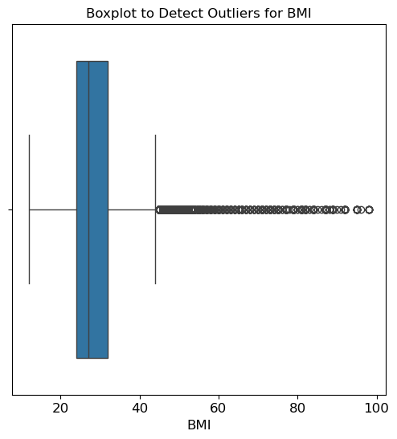

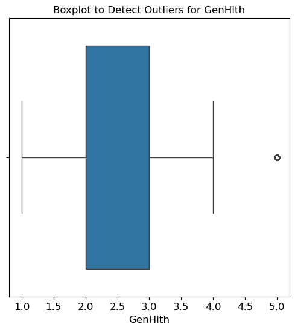

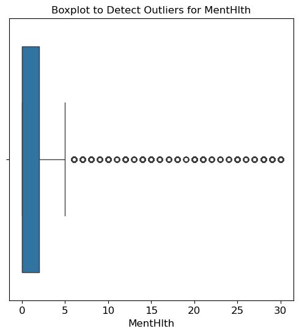

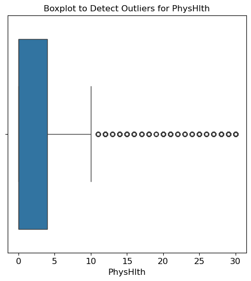

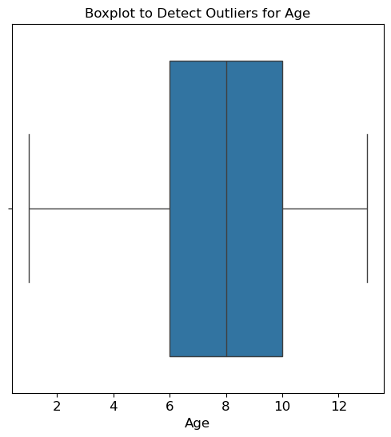

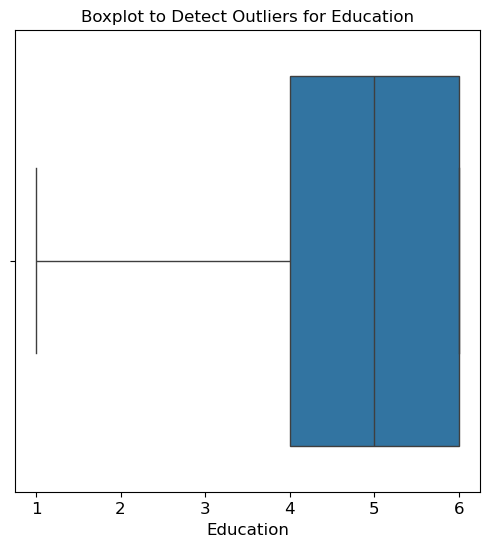

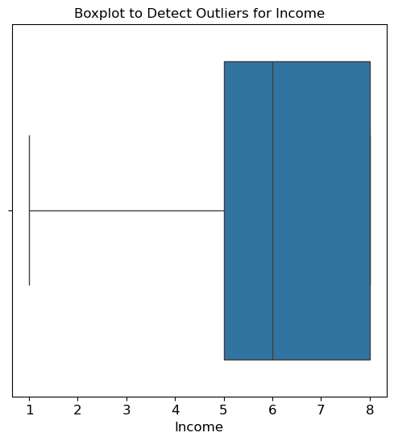

```python
#Investigate outliers in columns of interest using boxplots (you may include more but I do not recommend including dichotomous or low- and very low-cardinality ordinal variables)
cols = df1.iloc[:,[4,14,15,16,19,20,21]]
for col in cols:
    plt.figure(figsize=(6,6))
    plt.title(f'Boxplot to Detect Outliers for {col}', fontsize=12)
    plt.xticks(fontsize=12)
    plt.yticks(fontsize=12)
    sns.boxplot(x=df1[col])
    plt.xlabel(col, fontsize=12)
    plt.show()
```

Discussion point: Let's breakdown some of our findings from the boxplots

Let's continue by investigating and addressing the BMI outliers. We will discuss two methods

```python
#calculate 25th and 75th percentile as well as inter-quartile range. Calculate lower and upper limits
percentile25 = df1['BMI'].quantile(0.25)
percentile75 = df1['BMI'].quantile(0.75)
IQR = percentile75 - percentile25

upper_limit = percentile75 + 1.5 * IQR
lower_limit = percentile25 -1.5 * IQR
print("Lower limit:", lower_limit)
print("Upper limit:", upper_limit)
#identify outliers in our datasets
outliers = df1[(df1['BMI'] > upper_limit) | (df1['BMI'] < lower_limit)]
#print number of outliers
print("Number of rows in data containing outliers in 'BMI':", len(outliers))
```

```
Lower limit: 12.0
Upper limit: 44.0
Number of rows in data containing outliers in 'BMI': 5638
```

```python
#Compute z-scores for BMI
df1['BMI_z'] = zscore(df1['BMI'])

# Filter out high-BMI outliers (z > 3)
df1_outliers = df1[df1['BMI_z'] > 3]

# Show how many were flagged
print(f"Number of high-BMI outliers (z > 3): {len(df1_outliers)}")
```

```
Number of high-BMI outliers (z > 3): 2547
```

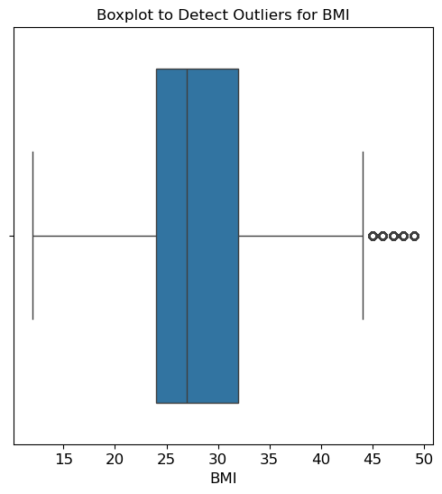

```python
#Visualize outliers
df_cleaned = df1.drop(df1_outliers.index)
plt.figure(figsize=(6, 6))
plt.title('Boxplot to Detect Outliers for BMI', fontsize=12)
plt.xticks(fontsize=12)
plt.yticks(fontsize=12)
sns.boxplot(x=df_cleaned['BMI'])
plt.xlabel('BMI', fontsize=12)
plt.show()
```

```python
#investigate dataframe for quartile/limit-based outliers
df_cleaned.describe()
```

|  | Diabetes_012 | HighBP | HighChol | CholCheck | BMI | Smoker | Stroke | HeartDiseaseorAttack | PhysActivity | Fruits | ... | NoDocbcCost | GenHlth | MentHlth | PhysHlth | DiffWalk | Sex | Age | Education | Income | BMI_z |
| --- | --- | --- | --- | --- | --- | --- | --- | --- | --- | --- | --- | --- | --- | --- | --- | --- | --- | --- | --- | --- | --- |
| count | 227234.000000 | 227234.000000 | 227234.000000 | 227234.000000 | 227234.000000 | 227234.000000 | 227234.000000 | 227234.000000 | 227234.000000 | 227234.000000 | ... | 227234.000000 | 227234.000000 | 227234.000000 | 227234.000000 | 227234.000000 | 227234.000000 | 227234.000000 | 227234.000000 | 227234.000000 | 227234.000000 |
| mean | 0.321440 | 0.452476 | 0.441646 | 0.959399 | 28.329898 | 0.466180 | 0.044676 | 0.103083 | 0.735660 | 0.613975 | ... | 0.092134 | 2.593133 | 3.471642 | 4.618415 | 0.181892 | 0.440317 | 8.099277 | 4.982630 | 5.900706 | -0.052425 |
| std | 0.720788 | 0.497737 | 0.496584 | 0.197365 | 5.790206 | 0.498856 | 0.206593 | 0.304068 | 0.440982 | 0.486837 | ... | 0.289216 | 1.061569 | 7.675186 | 8.991966 | 0.385756 | 0.496426 | 3.096050 | 0.992103 | 2.087362 | 0.853214 |
| min | 0.000000 | 0.000000 | 0.000000 | 0.000000 | 12.000000 | 0.000000 | 0.000000 | 0.000000 | 0.000000 | 0.000000 | ... | 0.000000 | 1.000000 | 0.000000 | 0.000000 | 0.000000 | 0.000000 | 1.000000 | 1.000000 | 1.000000 | -2.458712 |
| 25% | 0.000000 | 0.000000 | 0.000000 | 1.000000 | 24.000000 | 0.000000 | 0.000000 | 0.000000 | 0.000000 | 0.000000 | ... | 0.000000 | 2.000000 | 0.000000 | 0.000000 | 0.000000 | 0.000000 | 6.000000 | 4.000000 | 5.000000 | -0.690456 |
| 50% | 0.000000 | 0.000000 | 0.000000 | 1.000000 | 27.000000 | 0.000000 | 0.000000 | 0.000000 | 1.000000 | 1.000000 | ... | 0.000000 | 3.000000 | 0.000000 | 0.000000 | 0.000000 | 0.000000 | 8.000000 | 5.000000 | 6.000000 | -0.248391 |
| 75% | 0.000000 | 1.000000 | 1.000000 | 1.000000 | 32.000000 | 1.000000 | 0.000000 | 0.000000 | 1.000000 | 1.000000 | ... | 0.000000 | 3.000000 | 2.000000 | 4.000000 | 0.000000 | 1.000000 | 10.000000 | 6.000000 | 8.000000 | 0.488382 |
| max | 2.000000 | 1.000000 | 1.000000 | 1.000000 | 49.000000 | 1.000000 | 1.000000 | 1.000000 | 1.000000 | 1.000000 | ... | 1.000000 | 5.000000 | 30.000000 | 30.000000 | 1.000000 | 1.000000 | 13.000000 | 6.000000 | 8.000000 | 2.993412 |

8 rows × 23 columns

```python
#investigate dataframe for z-score-based outliers
df_cleaned_outliers = df1.drop(outliers.index)
df_cleaned_outliers.describe()
```

|  | Diabetes_012 | HighBP | HighChol | CholCheck | BMI | Smoker | Stroke | HeartDiseaseorAttack | PhysActivity | Fruits | ... | NoDocbcCost | GenHlth | MentHlth | PhysHlth | DiffWalk | Sex | Age | Education | Income | BMI_z |
| --- | --- | --- | --- | --- | --- | --- | --- | --- | --- | --- | --- | --- | --- | --- | --- | --- | --- | --- | --- | --- | --- |
| count | 224143.000000 | 224143.000000 | 224143.000000 | 224143.000000 | 224143.000000 | 224143.000000 | 224143.000000 | 224143.000000 | 224143.00000 | 224143.000000 | ... | 224143.000000 | 224143.000000 | 224143.000000 | 224143.000000 | 224143.000000 | 224143.000000 | 224143.000000 | 224143.000000 | 224143.000000 | 224143.000000 |
| mean | 0.315223 | 0.449552 | 0.440799 | 0.959147 | 28.077214 | 0.466461 | 0.044588 | 0.102747 | 0.73843 | 0.615000 | ... | 0.091281 | 2.582963 | 3.428793 | 4.557300 | 0.177886 | 0.442182 | 8.109979 | 4.985451 | 5.912471 | -0.089659 |
| std | 0.714994 | 0.497450 | 0.496484 | 0.197951 | 5.410090 | 0.498875 | 0.206397 | 0.303629 | 0.43949 | 0.486596 | ... | 0.288009 | 1.059038 | 7.622956 | 8.937287 | 0.382418 | 0.496647 | 3.100621 | 0.991841 | 2.082242 | 0.797202 |
| min | 0.000000 | 0.000000 | 0.000000 | 0.000000 | 12.000000 | 0.000000 | 0.000000 | 0.000000 | 0.00000 | 0.000000 | ... | 0.000000 | 1.000000 | 0.000000 | 0.000000 | 0.000000 | 0.000000 | 1.000000 | 1.000000 | 1.000000 | -2.458712 |
| 25% | 0.000000 | 0.000000 | 0.000000 | 1.000000 | 24.000000 | 0.000000 | 0.000000 | 0.000000 | 0.00000 | 0.000000 | ... | 0.000000 | 2.000000 | 0.000000 | 0.000000 | 0.000000 | 0.000000 | 6.000000 | 4.000000 | 5.000000 | -0.690456 |
| 50% | 0.000000 | 0.000000 | 0.000000 | 1.000000 | 27.000000 | 0.000000 | 0.000000 | 0.000000 | 1.00000 | 1.000000 | ... | 0.000000 | 3.000000 | 0.000000 | 0.000000 | 0.000000 | 0.000000 | 8.000000 | 5.000000 | 6.000000 | -0.248391 |
| 75% | 0.000000 | 1.000000 | 1.000000 | 1.000000 | 31.000000 | 1.000000 | 0.000000 | 0.000000 | 1.00000 | 1.000000 | ... | 0.000000 | 3.000000 | 2.000000 | 4.000000 | 0.000000 | 1.000000 | 10.000000 | 6.000000 | 8.000000 | 0.341027 |
| max | 2.000000 | 1.000000 | 1.000000 | 1.000000 | 44.000000 | 1.000000 | 1.000000 | 1.000000 | 1.00000 | 1.000000 | ... | 1.000000 | 5.000000 | 30.000000 | 30.000000 | 1.000000 | 1.000000 | 13.000000 | 6.000000 | 8.000000 | 2.256639 |

8 rows × 23 columns

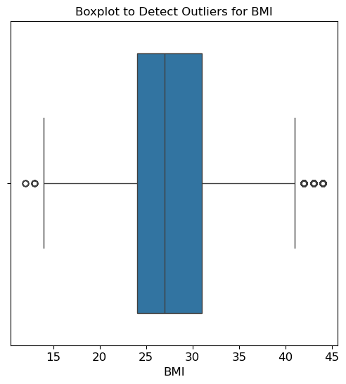

```python
plt.figure(figsize=(6, 6))
plt.title('Boxplot to Detect Outliers for BMI', fontsize=12)
plt.xticks(fontsize=12)
plt.yticks(fontsize=12)
sns.boxplot(x=df_cleaned_outliers['BMI'])
plt.xlabel('BMI', fontsize=12)
plt.show()
```

Two main considerations exist:

1. Z-scores are typically only used to confirm outliers in normally-distributed data but is more conservative in deleting values in this case
2. Using the IQR-based method does not assume normality and is less conservative in deleting values in this case.

I am moving forward by choosing to use the data cleaned by the z-score method because it

1. Is conservative: flags only the most extreme outliers in a distribution curve.
2. Preserves real, plausible data: Individuals with a BMI of 45-49 should be accounted for in analyses. It becomes another important topic of discussion to keep these datapoints when building ML models

```python
#We'll end the BMI cleaning by renaming the main dataframe
df2= df_cleaned
```

# PACE - Plan, Analyze, Construct, Execute

## Current Stage: Analyze

## Question #1: What percentage of individuals who responded to this survey had diabetes?

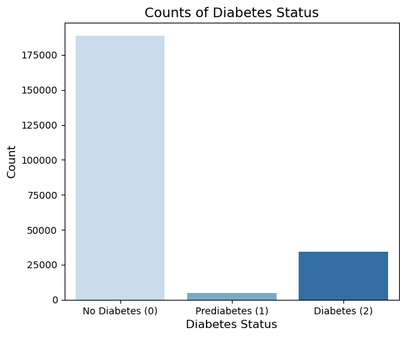

```
Percentage with diabetes and prediabetes: 15.07% and 2.00%, respectively.
```

```python
# Count the diabetes values
diabetes_counts = df2['Diabetes_012'].value_counts().sort_index()

# Create the bar plot
plt.figure(figsize=(6, 5))
barplot = sns.barplot(x=diabetes_counts.index, y=diabetes_counts.values, palette="Blues")

# Labels and title
plt.title('Counts of Diabetes Status', fontsize=14)
plt.xlabel('Diabetes Status', fontsize=12)
plt.ylabel('Count', fontsize=12)
plt.xticks([0, 1, 2], ['No Diabetes (0)', 'Prediabetes (1)', 'Diabetes (2)'])

plt.tight_layout()
plt.show()

percent_diabetes = df2['Diabetes_012'].value_counts(normalize=True)[2] * 100
percent_prediabetes = df2['Diabetes_012'].value_counts(normalize=True)[1] * 100
print(f"Percentage with diabetes and prediabetes: {percent_diabetes:.2f}% and{percent_prediabetes: .2f}%, respectively.")
```

## Question #2: What is the difference in the distribution of diabetes by age, sex, and income level?

```python
# create groupby clause to identify diabetes distribution across income levels
diabetes_by_income = (
    df2[df2['Diabetes_012'] == 2].groupby('Income').size() /
    df2.groupby('Income').size()
) * 100

print(diabetes_by_income.round(2))
```

```
Income
1.0    23.77
2.0    25.90
3.0    22.03
4.0    19.99
5.0    17.53
6.0    14.89
7.0    12.87
8.0     9.73
dtype: float64
```

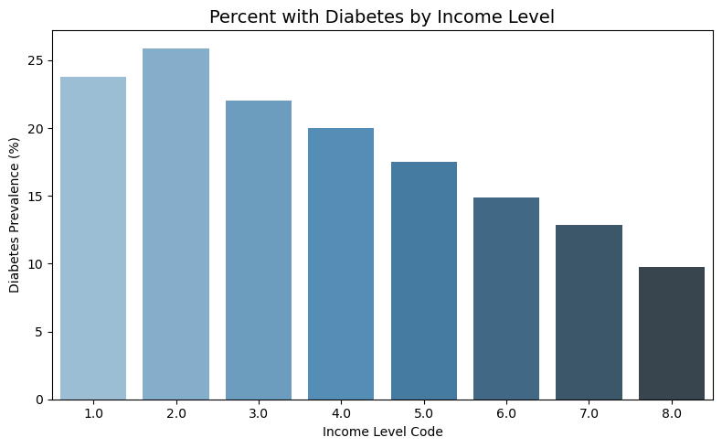

```python
#visualize groupby clause for diabetes and income levels
diabetes_by_income = (
    df2[df2['Diabetes_012'] == 2].groupby('Income').size() /
    df2.groupby('Income').size()
) * 100

# Plot
plt.figure(figsize=(8, 5))
sns.barplot(x=diabetes_by_income.index, y=diabetes_by_income.values, palette="Blues_d")
plt.title('Percent with Diabetes by Income Level', fontsize=14)
plt.xlabel('Income Level Code')
plt.ylabel('Diabetes Prevalence (%)')
plt.xticks(rotation=0)
plt.tight_layout()
plt.show()
```

```python
diabetes_by_age = (
    df2[df2['Diabetes_012'] == 2].groupby('Age').size() /
    df2.groupby('Age').size()
) * 100

print(diabetes_by_age.round(2))
```

```
Age
1.0      1.39
2.0      1.82
3.0      2.97
4.0      4.89
5.0      7.13
6.0      9.74
7.0     12.93
8.0     15.23
9.0     18.79
10.0    22.00
11.0    22.98
12.0    21.93
13.0    18.99
dtype: float64
```

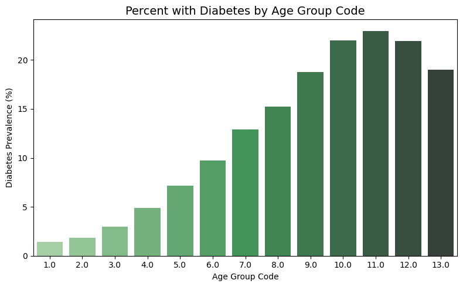

```python
# Calculate % diabetes by age group
diabetes_by_age = (
    df2[df2['Diabetes_012'] == 2].groupby('Age').size() /
    df2.groupby('Age').size()
) * 100

# Plot
plt.figure(figsize=(8, 5))
sns.barplot(x=diabetes_by_age.index, y=diabetes_by_age.values, palette="Greens_d")
plt.title('Percent with Diabetes by Age Group Code', fontsize=14)
plt.xlabel('Age Group Code')
plt.ylabel('Diabetes Prevalence (%)')
plt.xticks(rotation=0)
plt.tight_layout()
plt.show()
```

```python
#create groupby clause to investigate diabetes across sexes
diabetes_by_sex = (
    df2[df2['Diabetes_012'] == 2].groupby('Sex').size() /
    df2.groupby('Sex').size()
) * 100

print(diabetes_by_sex.round(2))
```

```
Sex
0.0    13.97
1.0    16.47
dtype: float64
```

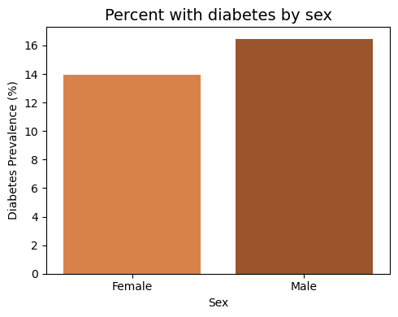

```python
#investigate groupby clause for diabetes and sex
diabetes_by_sex = (
    df2[df2['Diabetes_012'] == 2].groupby('Sex').size() /
    df2.groupby('Sex').size()
) * 100

# Plot
plt.figure(figsize=(5, 4))
sns.barplot(x=diabetes_by_sex.index, y=diabetes_by_sex.values, palette="Oranges_d")
plt.title('Percent with diabetes by sex', fontsize=14)
plt.xlabel('Sex')
plt.ylabel('Diabetes Prevalence (%)')
plt.xticks([0, 1], ['Female', 'Male'])
plt.tight_layout()
plt.show()
```

## Question #3: Among those with diabetes, what percentage are obese or physically inactive?

```python
#Create obesity status using established BMI cutpoints
df2['Obese'] = df2['BMI'] > 30
diabetics =df2[df2['Diabetes_012']==2]

Criteria = diabetics[(diabetics['Obese'] == 1) | (diabetics['PhysActivity'] ==0)]

percentage = len(Criteria) / len(diabetics) *100
print(f'Among those with diabetes, {percentage: .2f}% are obese or physically inactive')
```

```
Among those with diabetes,  66.22% are obese or physically inactive
```

```python
#create a function for 2x2 epidemiological tables
def generate_2x2_table(df, exposure_col, outcome_col, exposed_val=1, outcome_val=2):
    a = len(df[(df[exposure_col] == exposed_val) & (df[outcome_col] == outcome_val)])
    b = len(df[(df[exposure_col] == exposed_val) & (df[outcome_col] != outcome_val)])
    c = len(df[(df[exposure_col] != exposed_val) & (df[outcome_col] == outcome_val)])
    d = len(df[(df[exposure_col] != exposed_val) & (df[outcome_col] != outcome_val)])

    return pd.DataFrame(
        [[a, b], [c, d]],
        columns=['Disease: Yes', 'Disease: No'],
        index=['Risk Factor Present', 'Risk Factor Not Present']
    )
```

```python
#create 2x2 table to investigate the proportions of those with and without obesity and how diabetes count changes
table_oddsratio_Obesity = generate_2x2_table(df2,'Obese', 'Diabetes_012', exposed_val=1, outcome_val=2)
table_oddsratio_Obesity
```

|  | Disease: Yes | Disease: No |
| --- | --- | --- |
| Risk Factor Present | 17308 | 51582 |
| Risk Factor Not Present | 16938 | 141406 |

```python
#calculate odds ratios to investigate the odds of having diabetes for those with obesity
Obesity_table = table_oddsratio_Obesity.values
Obesity_res = odds_ratio(Obesity_table)
print(f"Odds Ratio:{Obesity_res.statistic: .2f}")
```

```
Odds Ratio: 2.80
```

```python
#create 2x2 table to investigate the proportions of physically active and inactive individuals and how diabetes count changes
table_oddsratio_PhysActivity = generate_2x2_table(df2,'PhysActivity', 'Diabetes_012', exposed_val=0, outcome_val=2)
table_oddsratio_PhysActivity
```

|  | Disease: Yes | Disease: No |
| --- | --- | --- |
| Risk Factor Present | 12516 | 47551 |
| Risk Factor Not Present | 21730 | 145437 |

```python
#calculate odds ratios to investigat the odds of having diabetes for those who are physically inactive
Activity_table = table_oddsratio_PhysActivity.values
Activity_res = odds_ratio(Activity_table)
print(f"Odds Ratio: {Activity_res.statistic: .2f}")
```

```
Odds Ratio:  1.76
```

Discussion point: Let's break down our first section of the Analyze phase.

1. Diabetes and prediabetes accounted for 17.07% of all survey respondents following data cleaning
2. Income and diabetes prevalence appear to share a negative relationship: lower-income individuals may be at a higher risk of developing diabetes. Diabetes prevalence is higher in older populations, with the highest prevalence in individuals 65-79. The prevalence of diabetes is slightly higher in males than in females.

   2b.Post-hoc analysis can be run to tease out further insights. For example, do lower-income individuals have less healthcare and have higher BMIs, do older people accrue less physical activity, and is the difference in prevalence of diabetes between men and women statistically meaningful?
3. The odds of getting diabetes are 180% higher if you are obese and 76% higher if you are inactive.

With a population size this large, our focus should largely shift away from "Are the observed differences statistically different?" (t-tests, ANOVA, Chi-Squared, correlation and regression coefficients) and instead to "Are the observed differences statistically meaningful?" (confidence intervals, effect size, regression betas, and odds ratios).

### Post hoc question 3: is the difference in prevalence of diabetes between men and women statistically meaningful?

```python
#test of independence and effect size for sex on diabetes
contingency_table_by_sex = generate_2x2_table(df2, 'Sex', 'Diabetes_012', exposed_val=1, outcome_val=2)
chi2, p, dof, expected = chi2_contingency(contingency_table_by_sex)

print(f"Chi-squared: {chi2:.2f}, p-value: {p:.6f}")
def cramers_v(confusion_matrix):
    chi2 = chi2_contingency(confusion_matrix)[0]
    n = confusion_matrix.sum().sum()
    return np.sqrt(chi2 / (n * (min(confusion_matrix.shape) - 1)))

cramers = cramers_v(contingency_table_by_sex)
print(f"Cramér's V: {cramers:.3f}")
```

```
Chi-squared: 272.05, p-value: 0.000000
Cramér's V: 0.035
```

small effect: <= 0.10 - 0.29

medium effect: 0.30 - 0.49,

large effect: >=0.50

We cannot conclude that the difference in diabetes prevalence between men and women is meaningful, despite statistical signficance

### Post hoc question 2: Do older people accrue less physical activity?

```python
#test of independence and effect size for age on physical activity
table = pd.crosstab(df2['Age'], df2['PhysActivity'] == 1)

chi2, p, dof, expected = chi2_contingency(table)
print(f"Chi-squared: {chi2:.2f}, p-value: {p:.4f}")
#calculate cramer's V
v_age = cramers_v(table)
print(f"Cramér's V for Age and Physical Activity: {v_age:.3f}")
```

```
Chi-squared: 2068.08, p-value: 0.0000
Cramér's V for Age and Physical Activity: 0.095
```

```python
#test of independence and effect size for income level on healthcare coverage.
#ANOVA for income level on BMI
display(Markdown("### **Post hoc question 1 (part 1): Are those with lower income more likely to report no healthcare coverage?**\n"))

table_Income = pd.crosstab(df2['Income'], df2['AnyHealthcare'] == 1)
chi2, p, dof, expected = chi2_contingency(table_Income)
print(f"Chi-squared: {chi2:.2f}, p-value: {p:.4f}")

v_Income_Healthcare = cramers_v(table_Income)
print(f"Cramér's V for Income and Healthcare: {v_Income_Healthcare:.3f}")

display(Markdown("### **Post hoc question 1 (part 2): Are those with lower income more likely to have an increased BMI?**\n"))
# Fit the ANOVA model
model = ols('BMI ~ C(Income)', data=df2).fit()
anova_table = sm.stats.anova_lm(model, typ=2)

# Extract only the 'C(Income)' row and relabel it
income_row = anova_table.loc[['C(Income)']].copy()
income_row.index = ['Income']
income_row = income_row.round(3)

# Display cleaned ANOVA summary
print("ANOVA Summary (Effect of Income on BMI):\n")
print(income_row)

# Calculate eta squared (η²)
ss_between = income_row.loc['Income', 'sum_sq']
ss_total = anova_table['sum_sq'].sum()
eta_squared = ss_between / ss_total

# F-statistic and degrees of freedom + p-value
f_stat = income_row.loc['Income', 'F']
df_model = int(income_row.loc['Income', 'df'])
df_resid = int(anova_table.loc['Residual', 'df'])
p_value = anova_table['PR(>F)'][0]

# Summary interpretation
print(f"\nSummary:")
print(f"F({df_model}, {df_resid}) = {f_stat:.2f}, p = {p_value:.5f}")
print(f"Eta squared (η²): {eta_squared:.3f}")
```

**Post hoc question 1 (part 1): Are those with lower income more likely to report no healthcare coverage?**

```
Chi-squared: 5099.57, p-value: 0.0000
Cramér's V for Income and Healthcare: 0.150
```

**Post hoc question 1 (part 2): Are those with lower income more likely to have an increased BMI?**

```
ANOVA Summary (Effect of Income on BMI):

           sum_sq   df        F  PR(>F)
Income  31302.343  7.0  133.926     0.0

Summary:
F(7, 227226) = 133.93, p = 0.00000
Eta squared (η²): 0.004
```

```python
# It's good practice to run a Tukey's post-hoc test when we see significant p-values to determine which groups differed.
#Additionally, we'll see how groups differed from each other to determine if our hypothesis of a negative relationship between income and BMI was true
if p_value < 0.05:
    print("\nTukey HSD post hoc test results:")
    tukey = pairwise_tukeyhsd(endog=df['BMI'], groups=df['Income'].astype(str), alpha=0.05)
    print(tukey.summary())
else:
    print("\nANOVA was not significant; skipping post hoc tests.")
```

```
Tukey HSD post hoc test results:
Multiple Comparison of Means - Tukey HSD, FWER=0.05
====================================================
group1 group2 meandiff p-adj   lower   upper  reject
----------------------------------------------------
   1.0    2.0   0.0631  0.997 -0.2092  0.3353  False
   1.0    3.0  -0.4807    0.0 -0.7361 -0.2253   True
   1.0    4.0  -0.7453    0.0 -0.9905    -0.5   True
   1.0    5.0  -0.9529    0.0  -1.189 -0.7167   True
   1.0    6.0  -1.0727    0.0 -1.2992 -0.8461   True
   1.0    7.0  -1.2927    0.0 -1.5154 -1.0699   True
   1.0    8.0  -2.1262    0.0 -2.3379 -1.9144   True
   2.0    3.0  -0.5438    0.0 -0.7856  -0.302   True
   2.0    4.0  -0.8084    0.0 -1.0394 -0.5773   True
   2.0    5.0  -1.0159    0.0 -1.2373 -0.7946   True
   2.0    6.0  -1.1358    0.0 -1.3468 -0.9247   True
   2.0    7.0  -1.3558    0.0 -1.5628 -1.1487   True
   2.0    8.0  -2.1892    0.0 -2.3843 -1.9941   True
   3.0    4.0  -0.2646 0.0036 -0.4756 -0.0536   True
   3.0    5.0  -0.4722    0.0 -0.6725 -0.2718   True
   3.0    6.0   -0.592    0.0 -0.7809 -0.4031   True
   3.0    7.0   -0.812    0.0 -0.9963 -0.6276   True
   3.0    8.0  -1.6455    0.0 -1.8163 -1.4746   True
   4.0    5.0  -0.2076 0.0177 -0.3948 -0.0204   True
   4.0    6.0  -0.3274    0.0 -0.5023 -0.1525   True
   4.0    7.0  -0.5474    0.0 -0.7174 -0.3774   True
   4.0    8.0  -1.3809    0.0 -1.5361 -1.2256   True
   5.0    6.0  -0.1198 0.3258 -0.2817  0.0421  False
   5.0    7.0  -0.3398    0.0 -0.4964 -0.1833   True
   5.0    8.0  -1.1733    0.0 -1.3137 -1.0329   True
   6.0    7.0    -0.22 0.0001 -0.3616 -0.0784   True
   6.0    8.0  -1.0535    0.0  -1.177 -0.9299   True
   7.0    8.0  -0.8335    0.0   -0.95  -0.717   True
----------------------------------------------------
```

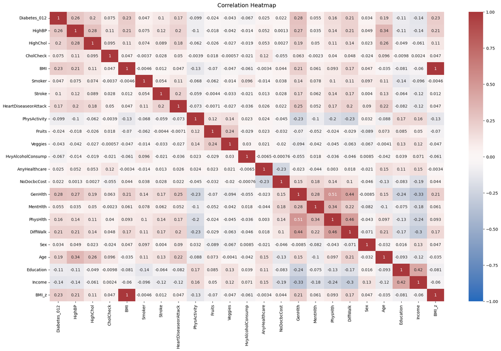

```python
# let's end off the second phase of our descriptive analytics phase by creating a correlation matrix.
# Even if there's not a correlation, these results can guide our use of ML models we use down the line
df_corr = df2.select_dtypes(include='number')

plt.figure(figsize=(22, 13))
heatmap = sns.heatmap(
    df_corr.corr(),
    vmin=-1,
    vmax=1,
    annot=True,
    cmap=sns.color_palette('vlag', as_cmap=True))
heatmap.set_title('Correlation Heatmap', fontdict={'fontsize': 14}, pad=12)
plt.show()
```

```python
#Get numerical features
df_corr = df2.select_dtypes(include='number')

#Compute correlation matrix
corr_matrix = df_corr.corr()

#Get correlation with the target (excluding the target itself)
target_corr = corr_matrix['Diabetes_012'].drop('Diabetes_012')

# Get absolute correlations (distance from 0), sort ascending
lowest_corr = target_corr.abs().sort_values()

# Optional: show features with correlation < threshold (e.g., 0.05)
weak_features = lowest_corr[lowest_corr < 0.09].index.tolist()

#display weak correlates
print("Features with lowest correlation to target:\n", weak_features)
```

```
Features with lowest correlation to target:
 ['NoDocbcCost', 'Fruits', 'AnyHealthcare', 'Sex', 'Veggies', 'Smoker', 'MentHlth', 'HvyAlcoholConsump', 'CholCheck']
```

## Don't forget you can double click the picture when you need to zoom in on values

Discussion point: Let's break down the final phase of our descriptive statistics phase. In this ad-hoc phase. we ran inferential tests to follow up on the findings from our descriptive tests.

# Inferential Statistics

## Inferential Statistics (question 1): is there a statistically meaningful difference in diabetes prevalence between individuals with high blood pressure and those without?

```python
# Generate contingency table (Stroke vs Diabetes)
contingency_table_stroke = generate_2x2_table(df2, 'HighBP', 'Diabetes_012', exposed_val=1, outcome_val=2)

# Chi-square test of independence
chi2, p, dof, expected = chi2_contingency(contingency_table_stroke)

v = cramers_v(contingency_table_stroke)

# Display results
print(f"\nChi-squared = {chi2:.2f}")
print(f"p-value = {p:.4f}")
print(f"Cramér’s V = {v:.3f}")
```

```
Chi-squared = 14407.79
p-value = 0.0000
Cramér’s V = 0.252
```

```python
display(Markdown("### **Inferential Statistics (question 2): What are the odds ratios for physically inactive individuals? \
 What about the odds ratios for physically active individuals?**\n"))

#Create cross-table for physical inactivity (ALREADY COMPLETED EARLIER. COPY AND PASTE)
table_oddsratio_PhysInactivity = generate_2x2_table(df2,'PhysActivity', 'Diabetes_012', exposed_val=0, outcome_val=2)
print(f'{table_oddsratio_PhysActivity}\n')

Inactivity_table = table_oddsratio_PhysInactivity.values
Inactivity_res = odds_ratio(Inactivity_table)
print(f"Odds Ratio for physically inactive individuals: {Inactivity_res.statistic: .2f}\n")

#Create cross-table for physical activity. Change exposed_val to 1.
table_oddsratio_PhysActivity = generate_2x2_table(df2,'PhysActivity', 'Diabetes_012', exposed_val=1, outcome_val=2)
print(f'{table_oddsratio_PhysActivity}\n')

Activity_table = table_oddsratio_PhysActivity.values
Activity_res = odds_ratio(Activity_table)
print(f"Odds Ratio for physically active individuals: {Activity_res.statistic: .2f}\n")
```

**Inferential Statistics (question 2): What are the odds ratios for physically inactive individuals? What about the odds ratios for physically active individuals?**

```
                         Disease: Yes  Disease: No
Risk Factor Present             12516        47551
Risk Factor Not Present         21730       145437

Odds Ratio for physically inactive individuals:  1.76

                         Disease: Yes  Disease: No
Risk Factor Present             21730       145437
Risk Factor Not Present         12516        47551

Odds Ratio for physically active individuals:  0.57
```

## While this is next question is technically a machine learning question (since we'd need to build a logistic regression model), we can circumvent building a predictive model and instead opt for an interpretive model with a few simple lines of code

```python
display(Markdown("### **Inferential statistics (question 3): What are the odds ratios for the sociodemographic factors on diabetes diagnosis? \
Describe the results relative to the referrent group**\n"))

#make a copy of the data
df_enc = df2.copy()

# Ensure categorical dtype
df_enc['Sex'] = df_enc['Sex'].astype('category')
df_enc['Education'] = df_enc['Education'].astype('category')
df_enc['Income'] = df_enc['Income'].astype('category')
df_enc['Age'] = df_enc['Age'].astype('category')

# Binary outcome: 1 = diabetes
df_enc['Diabetes_binary'] = (df_enc['Diabetes_012'] == 2).astype(int)

# Fit Logistic Regression
model = smf.logit('Diabetes_binary ~ C(Sex) + Age + C(Education) + C(Income)', data=df_enc)
result = model.fit()

# Create dataframe to show odds ratios with CI and p-values
conf = np.exp(result.conf_int())
odds_ratios = pd.DataFrame({
    "OR": np.round(np.exp(result.params), 2),
    "CI_lower": np.round(conf[0], 2),
    "CI_upper": np.round(conf[1], 2),
    "p-value": np.round(result.pvalues, 4)
})

#print(odds_ratios)
odds_ratios
```

**Inferential statistics (question 3): What are the odds ratios for the sociodemographic factors on diabetes diagnosis? Describe the results relative to the referrent group**

```
Optimization terminated successfully.
         Current function value: 0.392436
         Iterations 8
```

|  | OR | CI_lower | CI_upper | p-value |
| --- | --- | --- | --- | --- |
| Intercept | 0.03 | 0.02 | 0.05 | 0.0000 |
| C(Sex)[T.1.0] | 1.40 | 1.36 | 1.43 | 0.0000 |
| Age[T.2.0] | 1.50 | 1.12 | 2.00 | 0.0058 |
| Age[T.3.0] | 2.59 | 2.01 | 3.35 | 0.0000 |
| Age[T.4.0] | 4.54 | 3.57 | 5.78 | 0.0000 |
| Age[T.5.0] | 6.85 | 5.41 | 8.68 | 0.0000 |
| Age[T.6.0] | 9.45 | 7.49 | 11.92 | 0.0000 |
| Age[T.7.0] | 12.56 | 9.97 | 15.80 | 0.0000 |
| Age[T.8.0] | 15.08 | 11.99 | 18.96 | 0.0000 |
| Age[T.9.0] | 19.20 | 15.27 | 24.13 | 0.0000 |
| Age[T.10.0] | 23.22 | 18.48 | 29.18 | 0.0000 |
| Age[T.11.0] | 23.66 | 18.82 | 29.75 | 0.0000 |
| Age[T.12.0] | 21.29 | 16.92 | 26.80 | 0.0000 |
| Age[T.13.0] | 16.93 | 13.45 | 21.32 | 0.0000 |
| C(Education)[T.2.0] | 0.94 | 0.66 | 1.34 | 0.7237 |
| C(Education)[T.3.0] | 0.83 | 0.58 | 1.18 | 0.3078 |
| C(Education)[T.4.0] | 0.68 | 0.48 | 0.96 | 0.0302 |
| C(Education)[T.5.0] | 0.67 | 0.47 | 0.95 | 0.0253 |
| C(Education)[T.6.0] | 0.55 | 0.39 | 0.79 | 0.0010 |
| C(Income)[T.2.0] | 0.98 | 0.92 | 1.05 | 0.5743 |
| C(Income)[T.3.0] | 0.82 | 0.77 | 0.88 | 0.0000 |
| C(Income)[T.4.0] | 0.73 | 0.68 | 0.77 | 0.0000 |
| C(Income)[T.5.0] | 0.61 | 0.58 | 0.65 | 0.0000 |
| C(Income)[T.6.0] | 0.52 | 0.49 | 0.55 | 0.0000 |
| C(Income)[T.7.0] | 0.46 | 0.44 | 0.49 | 0.0000 |
| C(Income)[T.8.0] | 0.37 | 0.35 | 0.40 | 0.0000 |

Discussion point: Let's break down the second phase of our analysis (inferential statistics phase)

# PACE - Plan, Analyze, Construct, Execute

## Current Stage: Construct

There are many considerations we need to account for when entering this stage of our analytics project. As a reminder, most of our data types are mostly categorical. As a result, some machine learning models (e.g., principal component analysis, linear regression, support vector, and k-means) are not best suited for handling our data types. Additional resources are publicaly available that describe the ML models that I'll be using.

## Binomial Logistic Regression

Since we're going to be building a logistic regression model, we need to consolidate our target variable (diabetes status) to just two possible outcomes. Because only 2% of our dataset is cases of prediabetes, we're going to drop those cases so we have an unambiguous logistic regression classifier.

```python
# Drop prediabetes (1) and make a safe copy
df_logreg = df_enc[df_enc['Diabetes_012'] != 1].copy()
#encode the Obese category as integers instead of "True" and "False"
df_logreg['Obese'] = df_logreg['Obese'].astype(int)
#drop unwanted when defining feature selectioN
df_logreg= df_logreg.drop(columns=['Diabetes_binary','BMI_z'])
```

You'll see we dropped only about 4,550 rows of data. In the big picture, we will still have a very powerful classifier!

```python
#conduct feature selection by defining our y and X variables
y = df_logreg['Diabetes_012']
print(y.head())
print('-'*50)
X = df_logreg.drop(columns=['Diabetes_012'], errors='ignore')
X.head()
```

```
0    0.0
1    0.0
2    0.0
3    0.0
4    0.0
Name: Diabetes_012, dtype: float64
--------------------------------------------------
```

|  | HighBP | HighChol | CholCheck | BMI | Smoker | Stroke | HeartDiseaseorAttack | PhysActivity | Fruits | Veggies | ... | NoDocbcCost | GenHlth | MentHlth | PhysHlth | DiffWalk | Sex | Age | Education | Income | Obese |
| --- | --- | --- | --- | --- | --- | --- | --- | --- | --- | --- | --- | --- | --- | --- | --- | --- | --- | --- | --- | --- | --- |
| 0 | 1.0 | 1.0 | 1.0 | 40.0 | 1.0 | 0.0 | 0.0 | 0.0 | 0.0 | 1.0 | ... | 0.0 | 5.0 | 18.0 | 15.0 | 1.0 | 0.0 | 9.0 | 4.0 | 3.0 | 1 |
| 1 | 0.0 | 0.0 | 0.0 | 25.0 | 1.0 | 0.0 | 0.0 | 1.0 | 0.0 | 0.0 | ... | 1.0 | 3.0 | 0.0 | 0.0 | 0.0 | 0.0 | 7.0 | 6.0 | 1.0 | 0 |
| 2 | 1.0 | 1.0 | 1.0 | 28.0 | 0.0 | 0.0 | 0.0 | 0.0 | 1.0 | 0.0 | ... | 1.0 | 5.0 | 30.0 | 30.0 | 1.0 | 0.0 | 9.0 | 4.0 | 8.0 | 0 |
| 3 | 1.0 | 0.0 | 1.0 | 27.0 | 0.0 | 0.0 | 0.0 | 1.0 | 1.0 | 1.0 | ... | 0.0 | 2.0 | 0.0 | 0.0 | 0.0 | 0.0 | 11.0 | 3.0 | 6.0 | 0 |
| 4 | 1.0 | 1.0 | 1.0 | 24.0 | 0.0 | 0.0 | 0.0 | 1.0 | 1.0 | 1.0 | ... | 0.0 | 2.0 | 3.0 | 0.0 | 0.0 | 0.0 | 11.0 | 5.0 | 4.0 | 0 |

5 rows × 22 columns

```python
#split dataset into training and testing sets
X_train, X_test, y_train, y_test = train_test_split(X,y, test_size = 0.3, stratify = y, random_state=42)
```

```python
#train logistic regression
log_clf = LogisticRegression(random_state=42, max_iter=500).fit(X_train, y_train)
```

```python
#instruct logistic regression to predict on the X test data
y_pred = log_clf.predict(X_test)
```

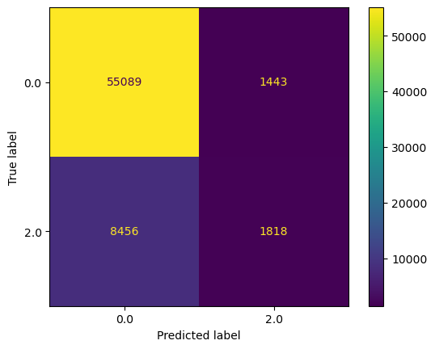

```python
# Compute values for confusion matrix
log_cm = confusion_matrix(y_test, y_pred, labels=log_clf.classes_)

# Create display of confusion matrix
log_disp = ConfusionMatrixDisplay(confusion_matrix=log_cm,
                                  display_labels=log_clf.classes_)

# Plot confusion matrix
log_disp.plot(values_format='')

# Display plot
plt.show()
```

```python
#Get a classification report: performance metrics of our logistic regression model
classifications = ['Predicted Healthy', 'Predicted Diabetes']
print(classification_report(y_test, y_pred, target_names=classifications))
```

```
                    precision    recall  f1-score   support

 Predicted Healthy       0.87      0.97      0.92     56532
Predicted Diabetes       0.56      0.18      0.27     10274

          accuracy                           0.85     66806
         macro avg       0.71      0.58      0.59     66806
      weighted avg       0.82      0.85      0.82     66806
```

We've not built a binomial logistic regression model that utilizes blood pressure, cholesterol, BMI, smoking status, etc. to predict if an individual has a positive or negative diabetes status. So far, we can see that this model performs very well when predicting healthy individuals, and performs relatively poorly when predicting positive diabetes status. Several potential factors could be contributing to these results (outliers we kept in the BMI category, multicollinearity between independent variables as we saw in our correlation matrix, and several other factors), but instead of trying to correct for them, we can accept these limitations and use this model as a baseline.

## Bernoulli Naive Bayes

```python
# Bernoulli Naive Bayes is based entirely on binary inputs, so we need to conduct some feature engineering.
# Let's move forward by binarizing our variables
#I'll be binarizing theese variables based on 1) large dropoffs in odds ratios from our interpretive LR model and 2) the median values
df_BNB = df_logreg.copy()
df_checkpoint = df_BNB.describe()
df_BNB['GenHlth'] = (df_BNB['GenHlth'] > 3).astype(int)
df_BNB['MentHlth'] = (df_BNB['MentHlth'] > 0).astype(int)
df_BNB['PhysHlth'] = (df_BNB['PhysHlth'] > 0).astype(int)

df_BNB['Age'] = df_BNB['Age'].astype(int)
df_BNB['Age'] = (df_BNB['Age'] > 8).astype(int)

df_BNB['Education'] = df_BNB['Education'].astype(int)
df_BNB['Education'] = (df_BNB['Education'] < 3).astype(int)

df_BNB['Income'] = df_BNB['Income'].astype(int)
df_BNB['Income'] = (df_BNB['Income'] == 1 ).astype(int)
#cols_of_interest = ['GenHlth','MentHlth', 'PhysHlth', 'Age','Education','Income','Diabetes_012','Diabetes_binary','BMI_z','BMI']
```

```python
#define features and target variables. Split dataset for training
y = df_BNB['Diabetes_012']
X = df_BNB.drop(['Diabetes_012'], axis=1)
X_train, X_test, y_train, y_test = train_test_split(X,y, test_size = 0.3, stratify = y, random_state = 42)
```

```python
#fitting our model with data
bnb_clf = BernoulliNB()
bnb_clf.fit(X_train, y_train)
```

```
BernoulliNB()
```

```python
#instructing our BNB model to predict based on X test data
y_pred_bnb = bnb_clf.predict(X_test)
```

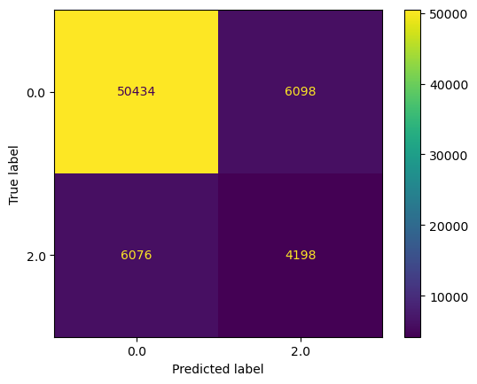

```
              precision    recall  f1-score   support

         0.0       0.89      0.89      0.89     56532
         2.0       0.41      0.41      0.41     10274

    accuracy                           0.82     66806
   macro avg       0.65      0.65      0.65     66806
weighted avg       0.82      0.82      0.82     66806
```

```python
#create confusion matrix for BNB model
bnb_cm = confusion_matrix(y_test, y_pred_bnb, labels= bnb_clf.classes_)
bnb_disp = ConfusionMatrixDisplay(confusion_matrix = bnb_cm, display_labels = bnb_clf.classes_)
bnb_disp.plot(values_format='')

plt.show()
print(classification_report(y_test, y_pred_bnb))
```

We've now built a Bernoulli Naive Bayes model and generated a classification report. We can see that there were some areas where the BNB model outperformed the logistic regression model, while in other places, the logistic regression model outperformed the BNB model.

I'd suggest playing around with which variables the model includes. You can drop all the binarized columns by telling X = df_BNB.drop to include the cols_of_interest we defined a few cells back, but this will reduce the model's ability to work with these columns down the road (with newer BRFSS datasets). I tend to prioritize generalizability over short-term increases in performance.

## XGBoost

```python
#define features and target variables
df_XGBoost = df_logreg.copy()

y = df_XGBoost['Diabetes_012'].map({0: 0, 2: 1})
X = df_XGBoost.drop(['Diabetes_012', 'NoDocbcCost', 'Fruits', 'AnyHealthcare', 'Sex', 'Veggies', 'Smoker', 'MentHlth', 'HvyAlcoholConsump', 'CholCheck'], axis =1)
X.info()
```

```
<class 'pandas.core.frame.DataFrame'>
Int64Index: 222684 entries, 0 to 253679
Data columns (total 13 columns):
 #   Column                Non-Null Count   Dtype
---  ------                --------------   -----
 0   HighBP                222684 non-null  float64
 1   HighChol              222684 non-null  float64
 2   BMI                   222684 non-null  float64
 3   Stroke                222684 non-null  float64
 4   HeartDiseaseorAttack  222684 non-null  float64
 5   PhysActivity          222684 non-null  float64
 6   GenHlth               222684 non-null  float64
 7   PhysHlth              222684 non-null  float64
 8   DiffWalk              222684 non-null  float64
 9   Age                   222684 non-null  category
 10  Education             222684 non-null  category
 11  Income                222684 non-null  category
 12  Obese                 222684 non-null  int32
dtypes: category(3), float64(9), int32(1)
memory usage: 18.5 MB
```

```python
#split dataset for modeling
X_train, X_test, y_train, y_test = train_test_split(X,y, test_size =0.3, stratify = y, random_state = 42)
```

```python
# one-hot encode categorical columns on train+test together to keep aligned columns
cat_cols = ['Age', 'Education', 'Income']
X_all = pd.concat([X_train, X_test], axis=0)
X_all_enc = pd.get_dummies(X_all, columns=cat_cols, drop_first=False)

X_train_enc = X_all_enc.iloc[:len(X_train), :].copy()
X_test_enc  = X_all_enc.iloc[len(X_train):, :].copy()

assert not X_train_enc.isnull().any().any()
assert not X_test_enc.isnull().any().any()
```

```python
# Class imbalance handling
scale_pos_weight = (y_train == 0).sum() / (y_train == 1).sum()

xgb = XGBClassifier(
    objective='binary:logistic',
    eval_metric='logloss',
    use_label_encoder=False,
    random_state=42,
    tree_method ='hist',
    scale_pos_weight=scale_pos_weight
)

# Hyperparameter grid
param_grid = {
    'max_depth': [6, 7, 8],
    'min_child_weight': [4, 5, 6],
    'gamma': [6, 7, 8],
    'learning_rate': [0.03, 0.05, 0.07],
    'subsample': [0.9, 1.0],
    'colsample_bytree': [0.4, 0.5, 0.6],
    'n_estimators': [100, 150]
}
#random search grid
random_search = RandomizedSearchCV(
    estimator=xgb,
    param_distributions=param_grid,
    n_iter=30,
    scoring='f1',
    cv=3,
    verbose=1,
    n_jobs=-1,
    random_state=42
)
```

```python
%%time
random_search.fit(X_train_enc, y_train) #fit the XGBoost model
```

```
Fitting 3 folds for each of 30 candidates, totalling 90 fits
```

```
CPU times: total: 17.5 s
Wall time: 5min 4s
```

```
RandomizedSearchCV(cv=3,
                   estimator=XGBClassifier(base_score=None, booster=None,
                                           colsample_bylevel=None,
                                           colsample_bynode=None,
                                           colsample_bytree=None,
                                           enable_categorical=False,
                                           eval_metric='logloss', gamma=None,
                                           gpu_id=None, importance_type=None,
                                           interaction_constraints=None,
                                           learning_rate=None,
                                           max_delta_step=None, max_depth=None,
                                           min_child_weight=None, missing=na...
                                           subsample=None, tree_method='hist',
                                           use_label_encoder=False,
                                           validate_parameters=None,
                                           verbosity=None),
                   n_iter=30, n_jobs=-1,
                   param_distributions={'colsample_bytree': [0.4, 0.5, 0.6],
                                        'gamma': [6, 7, 8],
                                        'learning_rate': [0.03, 0.05, 0.07],
                                        'max_depth': [6, 7, 8],
                                        'min_child_weight': [4, 5, 6],
                                        'n_estimators': [100, 150],
                                        'subsample': [0.9, 1.0]},
                   random_state=42, scoring='f1', verbose=1)
```

```
              precision    recall  f1-score   support

           0       0.91      0.88      0.89     56532
           1       0.43      0.50      0.46     10274

    accuracy                           0.82     66806
   macro avg       0.67      0.69      0.68     66806
weighted avg       0.83      0.82      0.83     66806
```

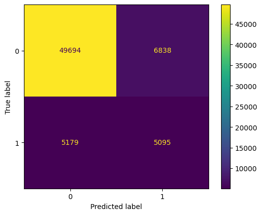

```python
# Predicted probabilities
y_proba = random_search.best_estimator_.predict_proba(X_test_enc)[:, 1]

# Choose custom threshold
new_threshold = 0.68
y_pred_adjusted = (y_proba >= new_threshold).astype(int)

# Evaluate
cm_adjusted = confusion_matrix(y_test, y_pred_adjusted)
disp = ConfusionMatrixDisplay(confusion_matrix=cm_adjusted)
disp.plot(values_format='')

print(classification_report(y_test, y_pred_adjusted))
```

```python
#identify the best params for this model
random_search.best_params_
```

```
{'subsample': 0.9,
 'n_estimators': 100,
 'min_child_weight': 4,
 'max_depth': 8,
 'learning_rate': 0.05,
 'gamma': 7,
 'colsample_bytree': 0.4}
```

```python
# XGBoost: Gain and Weight Importances
gain_importances = pd.DataFrame(
    random_search.best_estimator_.get_booster().get_score(importance_type='gain'),
    index=[0]
).T.rename(columns={0: 'gain_importance'})

weight_importances = pd.DataFrame(
    random_search.best_estimator_.get_booster().get_score(importance_type='weight'),
    index=[0]
).T.rename(columns={0: 'weight_importance'})

# Merge the two importances
XGB_importances = gain_importances.join(weight_importances, how='outer').fillna(0)

# Sort by gain importance for display
XGB_importances = XGB_importances.sort_values(by='gain_importance', ascending=False)

# Only keep features with non-zero importance in either metric
XGB_importances = XGB_importances[(XGB_importances['gain_importance'] != 0) | (XGB_importances['weight_importance'] != 0)]

# Show only top 7
XGB_importances.head(7)
```

|  | gain_importance | weight_importance |
| --- | --- | --- |
| HighBP | 3682.862061 | 48.0 |
| HighChol | 890.949280 | 79.0 |
| GenHlth | 686.231079 | 343.0 |
| Obese | 276.360962 | 88.0 |
| DiffWalk | 218.122726 | 192.0 |
| Age_2.0 | 121.935951 | 135.0 |
| Age_3.0 | 98.485992 | 188.0 |

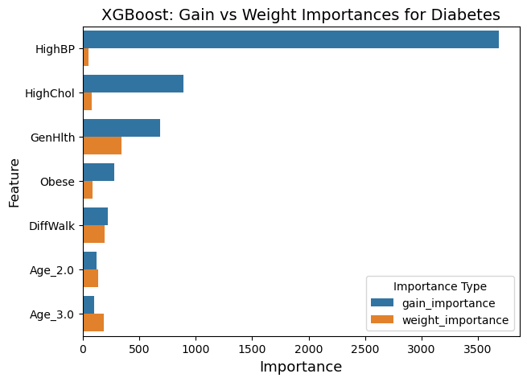

```python
# Visualize the top features (Gain vs Weight)
top_features = XGB_importances.head(7).reset_index().melt(id_vars='index', var_name='Importance_Type', value_name='Importance')
plt.figure(figsize=(7,5))
sns.barplot(data=top_features, x='Importance', y='index', hue='Importance_Type', orient='h')
plt.title("XGBoost: Gain vs Weight Importances for Diabetes", fontsize=14)
plt.ylabel("Feature", fontsize=12)
plt.xlabel("Importance", fontsize=13)
plt.legend(title='Importance Type')
plt.show()
```

## Machine Learning Question 1

Based on the models we created, the best model for classifying diabetes in BRFSS data appears to be the XGBoost

## Machine Learning Question 2

the top three variables that contribute to high gain importance are HigHBP, HighChol, and GenHlth

# PACE - Plan, Analyze, Construct, Execute

## Current Stage: Execute

## Project Overview

The logistic regression model achieve a weighted average precision of 82%, recall of 85%, and accuracy of 85% on the testing data set.

The XGBoost model modestly outperformed the Bernoulli Naive Bayes model. The performance metrics scores:

```
1) Accuracy: 82%
2) Recall: 82%
3) Precision: 83.0%
4) F1 Score: 83.0%
```

It's clear from our descriptive and inferential statistics phase that there are meaningful takeaways from this project.

1. The odds ratio for obesity and physical inactivity on diabestes highlights an important area of focus for policy change and health monitoring
2. Keeping blood pressure under control may significantly ameliorate some of the health consequences of diabetes while also potentially aiding in reduction of prevalence of diabetes. Perhaps the interested analyst could conduct a test that controls for blood pressure and physical activity to see if there's interplay between them and their effects on diabetes
3. Relative to 18-24 year olds, those who are 70-74 years of age have 23.66 times the odds of having diabetes. This highlights the importance of healthy lifestyles in the elderly

## Congrats on finishing the Diabetes analytics project. You've made significant strides in uncovering associations between lifestyle variables and diabetes diagnsosis, have built several impressive models, and have actionable items to address in research papers. Additionally, we can compare these results to other BRFSS datasets to make base future Naive Bayes models off of as well as examine secular changes